# Using Microsimulation to forecast household demand for electricity, given changes in poverty and equality

author: Chak Wong date: 10/13/2017 autosize: true

# Outline

- Background
- Introduction
- Microsimulation
- Methods
- Scenarios & Economic Policies
- Results
- Summary
- Next Steps

# Background

- The United Nations adopted the 2030 Sustainable Development Goals (SDGs), a call to action towards poverty eradication, environmental sustainability, and social equality.
- Sustainable Development: Human development goals are met and the economy maintains the natural systems’ ability to provide resources and ecosystem services.
- Ideally, it’s a society where living conditions and resource use meet human needs without undermining the natural systems’ stability.
- Realistically, it is difficult because of the complex linkages across economic, social, and environmental dimensions of sustainable development.
- This project strengthens policymakers’ capabilities to develop, analyze, and visualize modelled-based scenarios potentially useful for sustainable development.

# Introduction

- In developing countries, restrictive access to energy/electricity stagnates economic and social development.
- Helping the population below the poverty line with energy and income can solve key and related social and economic issues.
  - In South Africa, increased lighting [from houses] contributes to decreased rape rate.
- This project aims to understand the energy supply/demand equilibruim, by looking at how socioeconomic variables impacts the demand side.

# Microsimulation

What is it? - Computerized analytical tools used to evaluate the effects of proposed interventions - Compares baseline/reference and several alternate scenarios

Examples: - A traffic model evaluated the effectiveness of lengthening a turn lane - The Federal Reserve uses the Comprehensive Capital Analysis and Review (CCAR) method to regulate how banks invest under different economic scenarios (i.e. stress tests) - Our model evaluates a social program’s impact on the economy

# Microsimulation and Social Programs

This project: - Looks at how a social program that provides a cash transfer impacts energy consumption across different economic classes and economic scenarios - Randomly-sampled households were surveyed - Household income, socioeconomicdemographics, measured energy consumption - Actual data from Mauritius, Mexico, and Bolivia*

# Microsimulation Methodology

1. Data Collection
2. Data Cleaning and Recoding
3. Econometric Modelling: How income and sociodemographics impacts energy consumption
4. Coefficient Estimation: How the sample is generalizable to the general population
5. Creating Set of Policies: Cash Transfer
6. Define Target Population(s): Economic Classes
7. Microsimulation Results

# Methods

class: large-code Econometric Model:
$$latex
ln(Y_i) = \alpha_i + \beta_i ln(X_i) + {\delta_i}*{W_i} + \epsilon_i$$
- $Y_i$: energy consumption/demand - $\alpha_i$: constant related to each household - $\beta_i$: elasticity income-energy consumption/demand coefficient - $ln(X_i)$: log of income - $\delta_i$: coefficient associated to household variables, like sex, age, number of individuals, geographic area - $W_i$: household variables - $\epsilon_i$: measurement error

# Scenarios & Economic Policies

| Scenarios | Description | GDP Growth Rate |
| --- | --- | --- |
| Base | Income growth rate of 3% | 3.0% |
| Pro-poor | Bottom 50% received ~6.9 dollars to match the mean energy consumption | 3.0% |
| Pro-poor & Middle-Class | In addition to pro-poor policy, the middle-class (51-90%) received ~3.95 dollars (half of the energy consumption cost) | 3.0% |

# Results

[output not shown]

# Results of Scenarios & Economic Policies (Graphs)

[figure not shown]

***

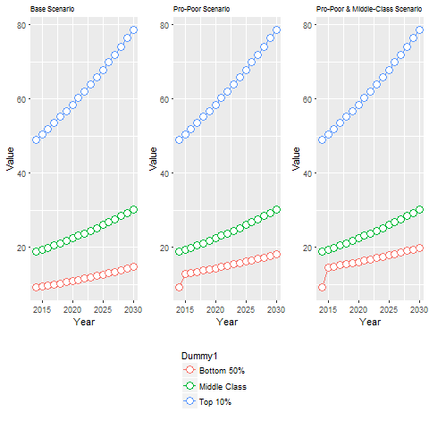

# Summary

- Marginal Effect between a shock in income and electricity demand.
- Bottom households with lowest income more elastic to shock in income compared to rest of population. Pro-poor policies were effective.
- Conclusion: Social programs can have a crucial, positive impact on electricity demand and on the economy.

# Next Steps

- Carto Products
- Builder
- Engine
  - Mobile SDK, Location Data Services, Data Observatory
- Spatial Econometrics
- Spatial Dependence/Autocorrelation, Spatial Analysis
- Spatial Econometrics Association

[figure not shown]

========================================================